# Class 23: Statistical Odds

Hughes/Fisher

## Review: What kind of model do we use for…

1. a numerical response with categorical predictors?

*2 sample t test, anova*

2. a numerical response with numerical predictors?

*multiple regression*

3. a numerical response with numerical and categorical predictors?

*multiple regression if no interaction, ancova if interaction*

4. a categorical response with numerical (or categorical) predictors?

*will learn this week, i think logistical regression*

## Statistical odds

**Motivating example: Cancer prevalence.** A random sample of patient records of 200 men (all of age 60) was collected to investigate the association between number of years smoking and presence of lung cancer. The data are in the file `cancerprev.csv`. The variables in the dataset are:

- `yrssmoke` - Number of years the subject has been a smoker
- `cancer` - Indicator variable of whether the subject has cancer (1) or not (0)

*QUESTIONS:*

- Which variable is the response variable in this problem? Which is the predictor variable? *Response: whether the subject has cancer, yes(1) or no(0), Predictor: number of years they have smoked*
- What is fundamentally different about this problem than any regression problem you’ve encountered to date? *the response has been a number before*

**EXERCISE:** Create a scatterplot of the response vs the predictor for the above example. Then, overlay a linear regression line on the plot.

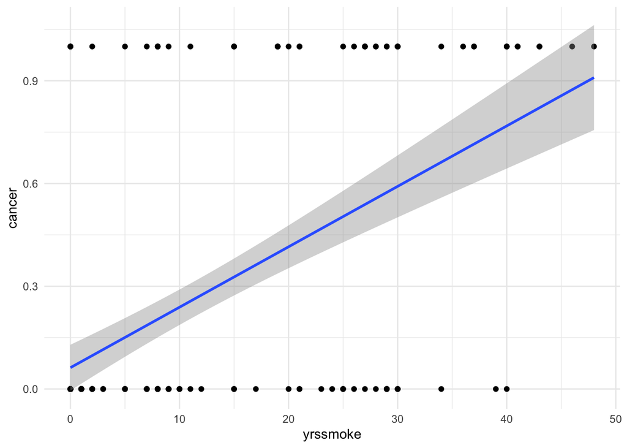

```r
cancerprev <- read.csv("cancerprev.csv")

ggplot(cancerprev, aes(x=yrssmoke, y=cancer)) +
  geom_point() +
  geom_smooth(method="lm") +
  theme_minimal()
```

*QUESTION:* Based on the above, why is a linear regression model inappropriate for these data? *Regression tries to estimate the mean response based for a function of predictor variables. Finding the average of cancer or no cancer is meaningless. Even if you considered this linear regression model for predicting the probability someone has cancer, you’ll notice the line will easily extrapolate outside the realm of the categorical responses.*

### Some Math

When we fit a regression model in all our previous problems, we are essentially modeling **the mean outcome of a response variable measured on a continuous scale**. The idea of regression is that this mean response can possibly be affected or influenced by other variables (i.e. the predictor variables). Mathematically, up to this point the models have been

$$\mu = E(Y) = \beta_0 + \beta_1X_1 + ... + \beta_pX_p$$

where $Y$ is normally distributed with mean $\mu | X_1, X_2, ..., X_p$ and constant variance $\sigma^2$ (that’s why we were always checking assumptions of normality, constant variance, etc). However, in the above cancer prevalence problem, the response is not a measured variable on a continuous scale; rather, **it is a binary classification** (do you have cancer: yes or no?). Because of this, the approach to modeling we have covered thus far does not apply.

You might (and should!) remember from your introductory statistics course that such a binary categorical variable is usually described, not with a **mean** parameter, but rather a **proportion** (or probability) $p$. The appropriate kind of probability model in this case is a **binomial distribution**.

### Review of the binomial distribution

What gives rise to the binomial distribution? Consider the following:

- We have a population that, as far as we are concerned consists of only two types of outcomes, which we generically refer to as **successes** and **failures**. The success outcome is the outcome of research interest (even if it doesn’t seem ‘right’ to call it a success, such as a patient has cancer!)
- We randomly sample $n$ individuals from the population. If sampling randomly, this ensures the observations are independent.
- The statistic of interest is $Y$ = the number of successes in the sample.

If these conditions are satisfied, then $Y$ is said to be binomially distributed with parameters $n$ and $p$. The parameter $p$ is actually the probability of a success, or $p=P(success)$, on any one sampled trial. The form of the probability distribution is given by:

$$P(Y=y)=\left(\frac{n!}{y!(n-y)!}\right) p^y(1-p)^{(n-y)}$$
for $y=0,1,2,.,n$.

In shorthand, we denote this by writing $Y \sim Bin(n, p)$. The expected value of a binomial variable is $np$, and the standard deviation of a binomial distribution is $\sigma = \sqrt{np(1-p)}$.

**The key ingredient we are interested in as researchers is $p$, the true probability of success.** Why is this of importance? Because it serves as a summary description of the outcome (response) in cases where the response variable is binary (the mean was the summary description for response variables that are continuous).

Consider the following:

- **Binomial scenario: Random guessing.** Suppose you are to take a quiz that has ten multiple-choice questions, where each question has 4 possible responses (of which only one is correct). You fail to study for the test, so you just randomly guess on every question. What is the chance you get exactly two of the questions right? If 60% is the minimum passing grade, what is the chance you fail the test?
  - QUESTION: What is $p$ in this scenario? *1/4*
- **Binomial scenario: Public opinion polling.** Suppose that 1000 Americans will be randomly polled and asked their opinion of whether they approve or disapprove of how President Trump is conducting his presidency. What is the chance that such a sample would produce an estimate of Trump’s approval rating that is correct to within a margin of error of $\pm$ 3% of the true value?
  - QUESTION: What is $p$ in this scenario? *the true proportion of the americans who approve of the president*
- **Binomial scenario: Cancer prevalence.** It is of interest to see if the prevalence of lung cancer among 60-year old men is affected by how long they have been a smoker. Each man in the population (or the sample) either has lung cancer or does not — so a binary outcome. Prevalence would be calculated by the estimating the proportion of men who have lung cancer with specific smoking histories (e.g. been a smoker for at least 10 years).
  - QUESTION: What is $p$ in this scenario? *the true proportion of all 60 year old men who have cancer (who smoked for 10 years)*

In real world applications, $p$ is unknown, and we are trying to estimate it. This can be easily done once a sample is collected from the population under study. An unbiased estimate of $p$ is
$$\hat{p} = \frac{\#~successes}{n}$$

This seems pretty simple. For example, in the above examples suppose:

- you guessed on the multiple-choice quiz and got only two questions correct. What is $\hat{p}$ based on your sample of 10 guesses? *2/10 = .2*
- in a random sample of 1000 Americans, 377 indicated approval of Donald Trump. What is $\hat{p}$ based on this sample? *377/1000 = .377*
- The below R code includes the necessary calculate to check the cancer prevalence among the sampled 60-year old men with a 10+ year history of smoking. What is $\hat{p}$? *38/(38+33) = 0.535*

```r
heavysmokers <-
 dplyr::filter(cancerprev, yrssmoke >= 10)
 xtabs(~cancer, data=heavysmokers)
```

```
## cancer
##  0  1
## 33 38
```

### Computing Odds

Another way of communicating this kind of summary information is in the form of **odds of success** (i.e. the odds of an event of interest occurring). The odds of an event is defined as the probability that the event happens divided by the probability it doesn’t happen, or

$$Odds = \frac{P(success)}{P(not~success)}$$
This can be estimated using the following:

$$Estimated~odds = \frac{ \frac{\#~successes}{n} }{ \frac{\#~failures}{n} } = \frac{\#~successes}{\#~failures}$$

**Cancer prevalence.** What are the estimated odds of lung cancer in a 60-year old male who has smoked at least 10 years? *38/33 = 1.151*

Note that while probabilities can only range between 0 and 1, **odds can be anything from 0 to $\infty$.**

### “I thought this was a regression course!”

It is, don’t worry! So how does all the above discussion link to regression modeling? Well, suppose that **the probability (or odds) of some event occurring is affected/related to other predictor variables.** For instance,

- the probability of a 60-year old man having lung cancer might be related to how long they have been a smoker
- the probability that you guess your instructor’s age correctly to within 3 years might be related to whether or not you are an international student (or gender, or your favorite time of day)

In such cases, we are (implicitly) building regression models, but the outcome is binary. The characteristic we will be modeling is the odds of the success outcome occurring.

**We will delve deeper into this concept on an upcoming in-class assignment!**

### Another illustration

The dataset `YouthRisk2007.csv` is derived from the 2007 Youth Risk Behavior Surveillance System (YRBSS), which is an annual survey conducted by the Centers for Disease Control and Prevention (CDC) to monitor the prevalence of health-risk youth behaviors. This datset focuses on whether or not youths have recently (in past 30 days) ridden with a drunk driver. The article *“Which Young People Accept a Lift From a Drunk or Drugged Driver?”* in Accident Analysis and Prevention (July 2009. pp. 703-9) provides more details.

The variables are:

- `ride.alc.driver`: Did the youth ride with a drinking driver in past 30 days?
- `female`: Is the youth a female?
- `grade`: Year in high school (9, 10, 11, or 12)
- `age`: Age (in years)
- `smoke`: Did the youth ever smoke?
- `driver.license`: Does the youth have a driver’s license?

```r
riskdata <- read.csv("YouthRisk2007.csv")

riskdata <- riskdata %>%
  mutate(grade = factor(grade)) %>%
  drop_na()

glimpse(riskdata)
```

```
## Observations: 12,282
## Variables: 6
## $ ride.alc.driver <fct> yes, yes, no, no, no, no, no, no, no, no, no, no, yes…
## $ female          <fct> yes, yes, no, no, no, no, no, no, yes, yes, no, yes, …
## $ grade           <fct> 10, 10, 11, 11, 11, 11, 11, 11, 11, 11, 11, 9, 9, 9, …
## $ age             <int> 15, 18, 17, 17, 17, 17, 17, 16, 17, 17, 18, 14, 15, 1…
## $ smoke           <fct> yes, yes, no, no, yes, no, yes, no, no, yes, yes, yes…
## $ driver.license  <fct> no, yes, yes, yes, yes, yes, yes, yes, yes, yes, yes,…
```

First, let’s compare sophomores to seniors:

```r
xtabs(~ grade + ride.alc.driver, data=riskdata)
```

```
##      ride.alc.driver
## grade   no  yes
##    9  2077  885
##    10 2114  944
##    11 2172  961
##    12 2070 1059
```

**QUESTIONS**: